# 13 Linear Model 4

Tobias Gerstenberg

2/6/2019

## Student feedback

### Datacamp

> This is just a comment about hw. But sometimes the data camp question can take a lot of time because I’m trying to figure out what I did wrong and it ended up the reason why was because I labelled things differently than what data camp recognizes. Looking at the answer is much more helpful than bashing, but we get docked for it. Is there a way to minimize this?

> I find the datacamp homework a bit frustrating. I’m familiar with a lot that is taught there and except for watching it in 1.5x speed, there is no way for me to skim through it. I would have liked to put more time instead into the second part of the homework which I found more challenging but I didn’t have any time left. So I felt that I spent more time on things I already knew and couldn’t focus on the things I actually needed practice in.

### Questions

> I’m having mixed feelings about both the frequency and time spent on questions in class – it makes following the narrative of the lecture that much harder…I’m wondering if there could be a better way for individual questions to be documented and resolved, perhaps via PollEV? Having a text box open throughout the class for people to type in their questions and reserve the last 15 mins of the class to address them? Not sure if this would work, just a thought…

### Contrasts

> is there any technique/ will we learn how to select the numbers for the contrast model (like 1, 1,4). Do you tell by looking at the data plots?

> Thanks for helping us reproduce the SPSS ANOVA. That’s really important for one of my projects. It’s hard that we’re getting bogged down and not able to get through as much material. But it is confusing, and I don’t understand some of it, so I don’t necessarily thing that powering ahead is helpful. Maybe covering materials and then letting people review it on their own and then come back to class with questions would be helpful. Also, thanks for all the effort you’ve put into the class. It’s fantastic, and we’re giving feedback to only try to make it better.

> I was confused on how we’re choosing the variables to encode the contrasts still? it seems arbitrary?

> Was a little confused about the mixed linear effects model at the end. Otherwise all made sense!

> Really really helpful and clear explanation of linear contrasts. Thank you!!

### Slides

> The posted PDFs of the slides are missing part of the additive slide content (e.g, slides 20 and 22nare missing code)

|  | response |
| --- | --- |
| 1 | I struggled with the concept of contrasts. Perhaps it would have helped to show analytically that applying this transformation to dummy-coded IVs does not affect anything but the interpretation of the… |
| 2 | This is just a comment about hw. But sometimes the data camp question can take a lot of time because I'm trying to figure out what I did wrong and it ended up the reason why was because I labelled thi… |
| 3 | Overall good. I thought the transition from a data exploration approach to a hypothesis testing approach wasn't made clear enough and make the section on setting up contrasts in advance at first a bit… |
| 4 | I'm having mixed feelings about both the frequency and time spent on questions in class -- it makes following the narrative of the lecture that much harder...I'm wondering if there could be a better w… |
| 5 | I find the datacamp homework a bit frustrating. I'm familiar with a lot that is taught there and except for watching it in 1.5x speed, there is no way for me to skim through it. I would have liked to … |
| 6 | is there any technique/ will we learn how to select the numbers for the contrast model (like 1, 1,4). Do you tell by looking at the data plots? |
| 7 | I followed why we could multiply our values by 0 and 1 earlier. But today, how does it not mess up our values when we multiply by -1, 0, 1, etc.? |
| 8 | The topic about ANOVA contrasts is always difficult to explain and I think you did a pretty good job. Keep it up! |
| 9 | Thanks for helping us reproduce the SPSS ANOVA. That's really important for one of my projects. It's hard that we're getting bogged down and not able to get through as much material. But it is confusi… |
| 10 | it seems like there are a ton of restrictions with linear/mixed effect modeling eg normal residuals...can we use permutation test to circumvent these issues with these more complicated models? |

[output cut: 4 more lines]

### PollEverywhere results

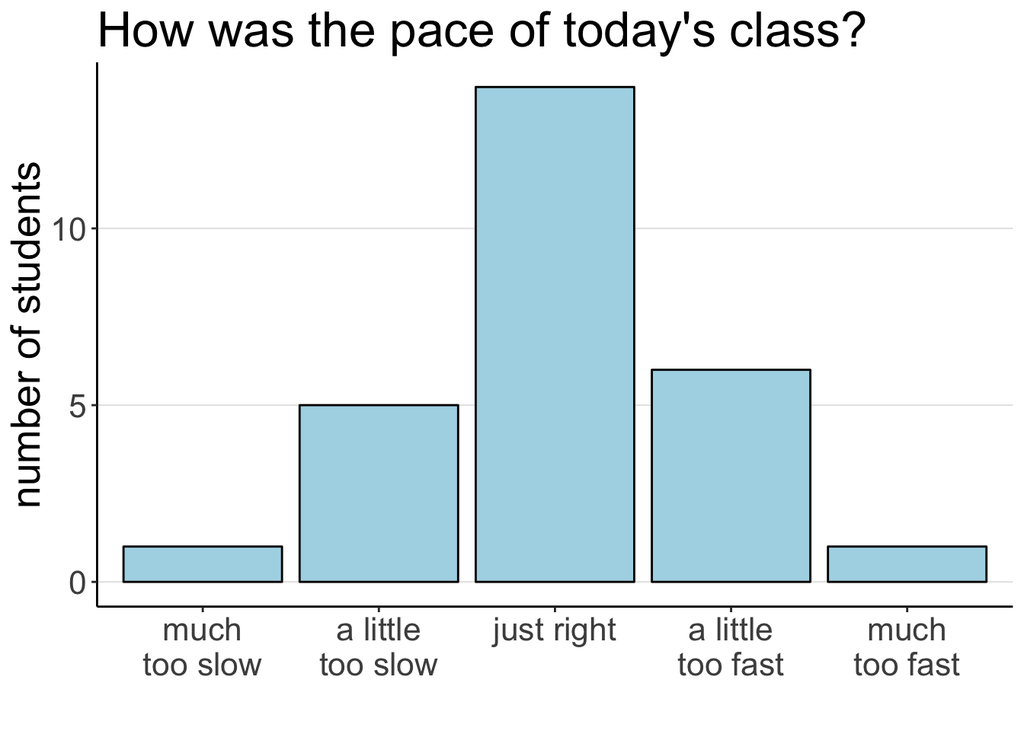

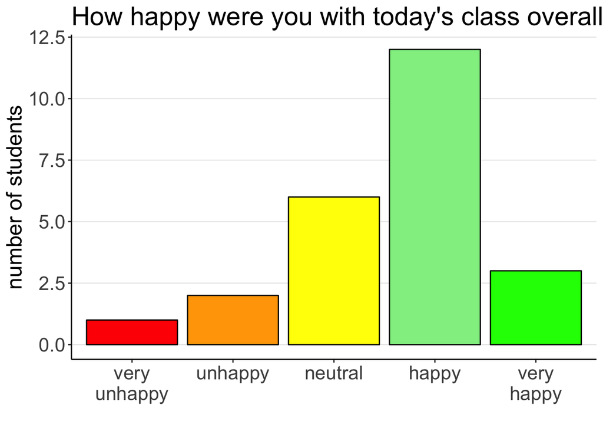

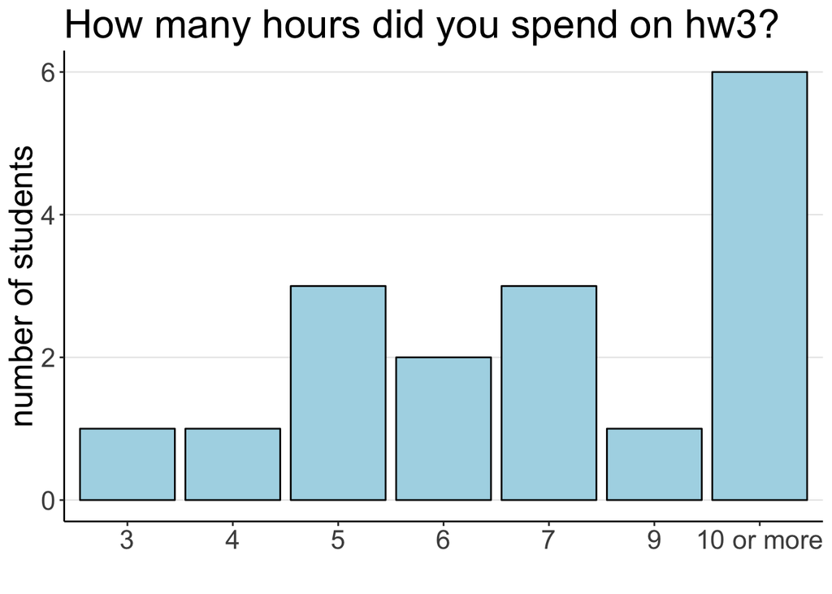

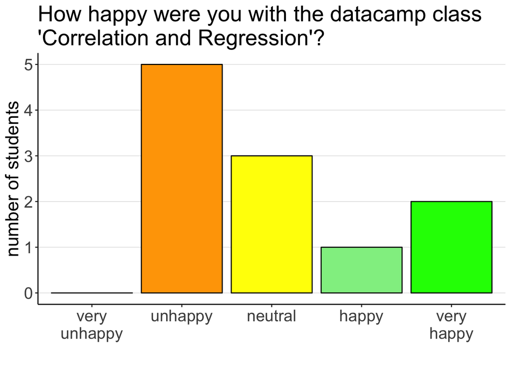

## What to do next time

- fix mistakes on plot axis labels
- fix some equations (the order of $b$ and dummy variable was flipped)
- only managed to get until slide 44; maybe have some periods of time without taking questions?!
- don’t assign “correlation and regression” data camp course next time
- define the quadratic contrast in the example as orthogonal (rather than just using the I(group^2) notation)
- rewrite the ANOVA model simulation code so tha the intercepts encode main effects rather than simple effects
- show the $SS_{\text{residual}}$ for the two-way additive ANOVA
- explain what “contr.sum” does
- don’t use white rectangles to cover equations (since they block the equations in the pdfs …)